# Introdução às Séries Temporais para Ciências Atuariais

Marcos R. Gonzaga (UFRN)

20-04-2026

### **1. Introdução**

Bem-vindo ao curso de Séries Temporais Aplicadas às Ciências Atuariais. Este material foi estruturado para oferecer uma visão prática e fundamentada sobre como o comportamento de variáveis ao longo do tempo influencia a análise de riscos e a modelagem biométrica e financeira.

O foco principal desta jornada é a aplicação direta. Exploraremos conceitos essenciais, definições fundamentais e exemplos práticos que fazem parte do cotidiano do atuário.

É importante destacar que trata-se de um conteúdo de nível introdutório, ideal para quem está iniciando os estudos na área. Priorizam-se a compreensão das técnicas e sua utilidade em problemas diversos, sem a pretensão de esgotar as complexas demonstrações matemáticas ou os fundamentos teóricos mais densos.

Para aqueles que desejam dominar o rigor estatístico e as nuances dos cálculos subjacentes, disponibiliza-se uma seção de referências bibliográficas recomendadas ao final do curso.

Ao longo do material, você será guiado pela metodologia de análise, desde a identificação de componentes de uma série (como tendência e sazonalidade) e a investigação de suas características, até a identificação de modelos de previsão mais adequados para cada situação.

#### **1.1 Séries Temporais (Definição)**

Entender Séries Temporais é como aprender a ler o “ritmo” dos dados. Diferente de uma análise convencional onde os dados são independentes, aqui a ordem dos fatores altera (e muito) o produto.

**O Conceito:

Uma série temporal é, grosso modo, um conjunto de observações coletadas em intervalos de tempo sucessivos e (geralmente) iguais. O segredo está na *autocorrelação*: o valor de hoje depende, em algum nível, do valor de ontem. Neste curso, toda série temporal será identificada genericamente por $z_t$.

Todo modelo de séries temporais é divido em ao menos 3 componentes principais:

- **Tendência**: A direção de longo prazo (está subindo ou descendo).
- **Sazonalidade**: Padrões que se repetem em intervalos fixos (ex: vendas de sorvete no verão).
- **Ruído (Erro)**: A variação aleatória que não conseguimos explicar.

Adicionalmente algumas séries podem apresentar flutuações de longo prazo sem período fixo chamados de clicos (ex: ciclos econômicos).

**O modelo na forma geral:**

Podemos escrever $z_t$ como uma soma de três componentes não observáveis (modelo aditivo):

$$\large
Z_t=T_t+S_t+a_t\hspace{3cm}(1.1)$$
onde:

- $Z_t$ é o valor da série em cada ponto do tempo t;
- $T_t$ é a tendência (determinística/estocástica) que a série possui ao longo do tempo;
- $a_t$ é o resíduo ou o erro aleatório do modelo que, em geral, trata-se de uma sequência aleatória com média zero e variância constate.

Em situações onde o efeito sazonal da série aumenta sua variabilidade na medida em que a série se desenvolve, tem-se um modelo multiplicativo da forma:

$$\large Z_t=T_t\times
S_t+a_t\hspace{3cm}(1.2)$$
As componentes $T_t$ e $S_t$ são, em geral, muito relacionadas no sentido que a tendência exerce influência sobra a sazonalidade por duas razões:

- Métodos de estimação de $S_t$ podem ser bastante afetados se não levarmos em conta a tendência.
- A especificação de $S_t$ depende da especificação de $T_t$.

Neste caso, não podemos isolar uma das componentes sem tentar isolar a outra. Nos modelos (1.1) e (1.2) estimando-se $T_t$ e $S_t$ e subtraindo de $Z_t$ obtem-se uma estimativa de $a_t$.

**CURIOSIDADE**

Uma dúvida comum para quem inicia os estudos nesta área é: *o que os modelos de análises de séries temporais trazem de novo em relação aos modelos de análise de regressão*?

A resposta reside na *estrutura de dependência dos dados*. Enquanto a regressão tradicional pressupõe que as observações são independentes, a metodologia de séries temporais reconhece que o passado influencia diretamente o presente. Segundo Shumway and Stoffer (2006), a correlação introduzida pela amostragem de pontos adjacentes no tempo restringe severamente a aplicabilidade de métodos estatísticos convencionais, os quais se baseiam na suposição de que as observações são independentes e identicamente distribuídas (i.i.d.).

Por exemplo, em uma abordagem por *regressão convencional*, o atuário tentaria prever o valor dos sinistros baseando-se apenas em variáveis externas, como o número de veículos segurados ou a inflação de autopeças. Se o modelo ignorar a dimensão temporal, tratará o volume de sinistros de janeiro como um evento totalmente independente do ocorrido em dezembro.

Em contrapartida, em uma abordagem por *séries temporais*, o atuário compreende a existência de uma dependência temporal. Se houve um aumento repentino de sinistros no mês anterior — devido a uma enchente ou a uma mudança na política de aceitação —, esse efeito “residual” tende a persistir nos meses subsequentes. Frequentemente, observa-se um maior volume de sinistros em períodos de férias (dezembro/janeiro) em decorrência do maior fluxo de viagens (sazonalidade). Adicionalmente, o custo médio dos reparos pode aumentar progressivamente ao longo do tempo. De modo geral, o valor observado do número de sinistros hoje é, em parte, uma função do valor observado ontem.

Se utilizarmos uma regressão comum em contextos onde os dados são autocorrelacionados, obteremos estimativas de erro padrão subestimadas. Isso resulta em intervalos de confiança falsamente precisos e em uma percepção de risco distorcida. Em previdência ou seguros, por exemplo, ignorar a estrutura temporal pode resultar em reservas técnicas insuficientes ou em um apreçamento (pricing) inadequado do prêmio.

#### **1.2 A natureza dos dados de séries temporais**

Antes de aplicar modelos matemáticos complexos ou algoritmos de previsão, todo analista — e especialmente o atuário — deve se dedicar a investigar a natureza intrínseca dos dados. Este é o primeiro e mais crucial passo de qualquer análise de séries temporais.

O objetivo primordial desta etapa é realizar uma “anatomia” dos dados, decompondo o que parece ser um comportamento aleatório em componentes identificáveis e interpretáveis. Somente ao compreender essas características é que podemos selecionar o modelo adequado para mitigar riscos e projetar cenários futuros.

Para caracterizar uma série, buscamos identificar, numa inspeção visuaL, os componentes que determinam o comportamento da série: **Tendência**, **Sazonalidade** e **Variabilidade** (Ruído). A inspeção visual, muitas vezes negligenciada, revela comportamentos que testes estatísticos isolados podem ocultar, como: *Valores Atípicos* (por exemplo, um sinistro de valor astronômico que pode distorcer a média); *Quebras Estruturais* (mudanças súbitas no comportamento da série devido a alterações na legislação ou pandemias, por exemplo) e *Ciclos* (Flutuações de longo prazo associadas a ciclos econômicos que afetam, por exemplo, a taxa de juros e, consequentemente, o valor presente das obrigações atuariais).

Sem uma compreensão clara dessas características, o risco do “ruído” ser interpretado como “sinal” é alto, levando a modelos que falham justamente nos momentos de maior necessidade de solvência.

OBSERVAÇÃO: a análise gráfica de uma série temporal é útil não somente para identificar padrões e características da série mas, ainda, identificar valores discrepantes ou inconsistentes. Tais valores, por vezes, precisam ser desconsiderados ou tratados de forma diferenciada na análise.

**Exemplos:**

As análises a seguir baseiam-se na visualização gráfica de séries temporais. Procede-se à análise das características que definem o comportamento de cada série, as quais constituem o ponto de partida para qualquer análise descritiva de séries temporais.

A **Figura 1** apresenta os ganhos trimestrais por ação da empresa Johnson & Johnson. O conjunto de dados compreende 84 trimestres (21 anos), mensurados do primeiro trimestre de 1960 ao último trimestre de 1980. A série exibe uma tendência gradualmente crescente, com variações sazonais que se repetem nos trimestres de cada ano e aumentam sua variabilidade ao longo do tempo. Outra característica relevante é o fato de a tendência apresentar um crescimento exponencial, configurando-se como uma *tendência determinística*.

Figura 1 - Ganhos trimestrais por ação da empresa Johnson & Johnson (1960-1980)

```r
jj <- lista_dados$jj
jj.ts <- ts(jj, start=1960, frequency=4)

# Gráfico interativo:
dygraph(jj.ts, main = "") %>%
  dyRangeSelector(height = 40) %>% # Adiciona a barra de zoom em baixo
  dySeries("V1", label = "Ganhos por ação") %>% # Nomeia a série de dados
  dyOptions(fillGraph = TRUE, fillAlpha = 0.1) %>% # Adiciona uma sombra suave sob a linha
  dyHighlight(highlightCircleSize = 5,  # Destaca os pontos ao passar o mouse
              highlightSeriesBackgroundAlpha = 0.2,
              hideOnMouseOut = FALSE)
```

[interactive chart not shown]

Fonte: Shumway and Stoffer (2006).

A **Figura 2** apresenta uma série de registros de anomalias de temperatura global. Observa-se uma tendência ascendente, que fundamenta a hipótese do aquecimento global. Nota-se, ainda, um nivelamento até por volta de 1935, seguido por uma nova tendência de elevação acentuada até 1970, como novo nivelamente até por volta de 2000, seguido por outra tendência de aumento até o ano final de observação. Especialistas e defensores da teoria do aquecimento global argumentam que a tendência exibida pela série é consequência da interferência antrópica (ação humana).

Figura 2 - Registro anual da temperatura global no planeta (1880-2021)

```r
globtemp <- lista_dados$globtemp
globtemp.ts <- ts(globtemp, start=1880)
# Gráfico interativo
dygraph(globtemp.ts, main = "") %>%
  dyRangeSelector(height = 40) %>%               # Adiciona a barra de zoom em baixo
  dySeries("V1", label = "Temperatura") %>% # Nomeia a série de dados
  dyOptions(fillGraph = TRUE, fillAlpha = 0.1) %>% # Adiciona uma sombra suave sob a linha
  dyHighlight(highlightCircleSize = 5,             # Destaca os pontos ao passar o rato
              highlightSeriesBackgroundAlpha = 0.2,
              hideOnMouseOut = FALSE)
```

[interactive chart not shown]

Fonte: Shumway and Stoffer (2006)).

A **Figura 3** apresenta a série temporal do número mensal de passageiros aéreos nos Estados Unidos, abrangendo o período de janeiro de 1949 a dezembro de 1960. Quanto às suas características, observa-se que a série possui uma tendência de crescimento aproximadamente linear acompanhada de uma variação sazonal anual (ciclos que se repetem dentro de cada ano) com variabilidade crescente ao longo do tempo. Esse padrão reflete o comportamento do mercado de aviação da época, com picos de demanda entre junho e agosto e retrações por volta de novembro.

Dentre as hipóteses para os determinantes do comportamento dessa série, destacam-se:

1. Prosperidade econômica;
2. Maior disponibilidade de aeronaves;
3. Redução de preços decorrente da competição;
4. Crescimento populacional;
5. Ciclos sazonais coincidentes com períodos de férias escolares e de verão.

Figura 3 - Análise do número mensal de passageiros aéreos, Estados Unidos (1949-1960)

```r
data("AirPassengers")
AP = AirPassengers

# Gráfico interativo:
dygraph(AP, main = "") %>%
  dyRangeSelector(height = 40) %>%  # Adiciona a barra de zoom em baixo
  dySeries("V1", label = "Passageiros") %>% # Nomeia a série de dados
  dyOptions(fillGraph = TRUE, fillAlpha = 0.1) %>% # Adiciona uma sombra suave sob a linha
  dyHighlight(highlightCircleSize = 5, # Destaca os pontos ao passar o mouse
              highlightSeriesBackgroundAlpha = 0.2,
              hideOnMouseOut = FALSE)
```

[interactive chart not shown]

Fonte: Box and Jenkins (1976).

A **Figura 4** apresenta a série temporal da variação mensal do IPCA, simulada com base em dados reais no período de 2015 a 2023. A série exibe ausência de tendência. Diferentemente do índice acumulado, que possui uma tendência de crescimento (não estacionária), a taxa de variação mensal do IPCA oscila horizontalmente em torno de uma média. Para o atuário, isso sugere que, no longo prazo, a inflação média tende a uma estabilização relativa. Caso houvesse uma tendência de alta na variação (aceleração inflacionária), as reservas técnicas indexadas poderiam sofrer um descasamento severo (risco de base).

A série simulada não apresenta padrões sazonais repetitivos. Entretanto, em cenários reais, o IPCA pode apresentar uma leve sazonalidade em função, por exemplo, de reajustes no mês de janeiro devido às mensalidades escolares. Nesta série específica, os picos e vales ocorrem de forma aleatória. Em modelos reais, caso a sazonalidade fosse identificada, o atuário precisaria aplicar ajustes sazonais para evitar a confusão entre um pico cíclico e uma mudança estrutural no risco.

A variabilidade da série é aparentemente constante ao longo do tempo, caracterizando a homocedasticidade. A “nuvem” de pontos mantém uma dispersão similar ao longo de todo o período observado, concentrando-se predominantemente entre $0\%$ e $1\%$.

Ainda sobre a **Figura 4**, observa-se que a volatilidade controlada facilita a construção de intervalos de confiança. Se a variabilidade aumentasse ao longo do tempo (heterocedasticidade), o atuário seria compelido a elevar as margens de segurança para mitigar o risco de insolvência em cenários de estresse, por exemplo. Sempre que a série atinge um valor extremo (como próximo a 1%), ela tende a retornar ao seu valor médio de $0,45\%$ (identificado pela linha vermelha tracejada) nos períodos subsequentes.

Em síntese, a série é classificada como estacionária na média e na variância, sendo esta uma propriedade fundamental para a aplicação dos modelos de previsão que serão discutidos adiante.

Figura 4 - Variação Mensal do IPCA (%) (2015-2023) - Exemplo de Série Estacionária

```r
# Simulação de dados reais baseados no comportamento do IPCA (2015-2023)
set.seed(123)
meses <- seq(as.Date("2015-01-01"), as.Date("2023-12-01"), by = "month")
# Criando uma série com média 0.45% e desvio padrão de 0.25 (comportamento típico do IPCA)
variacao_ipca <- ts(rnorm(length(meses), mean = 0.45, sd = 0.25),
                    start = c(2015, 1), frequency = 12)

# Gráfico interativo:
dygraph(variacao_ipca, main = "") %>%
  dyAxis("y", label = "Variação Mensal (%)") %>%
  dySeries("V1", label = "IPCA Mensal", color = "#2c3e50") %>%
  dyOptions(drawPoints = TRUE, pointSize = 2) %>%
  dyLimit(mean(variacao_ipca), "Média Histórica", strokePattern = "dashed", color = "red") %>%
  dyRangeSelector(height = 40)
```

[interactive chart not shown]

Fonte: Série Simulada.

#### **1.3 Investigando a sazonalidade e a tendência**

Em muitas situações práticas, $z_t$ é uma série temporal que apresenta algum tipo de tendência. Ao removermos a componente de tendência, a série torna-se estacionária; isto é, passa a apresentar média e variância constantes ao longo do tempo. Por vezes, é fundamental remover a sazonalidade para obter maior clareza sobre o comportamento da tendência da série — por exemplo, para identificar se ela cresce ou decresce com o tempo e se possui um comportamento determinístico (linear, exponencial, entre outros). Da mesma forma, é relevante investigar a sazonalidade isolada da componente de tendência. A seguir, apresentam-se exemplos de como conduzir essa investigação.

No código da **Figura 5**, ao aplicar a função `aggregate` na série número mensal de passagens aéreas, produz-se o resultado apresentado na Figura 5, que permite investigar a componente de tendência após a remoção da sazonalidade. A análise do gráfico resultante sugere que a tendência da série pode não ser estritamente linear, apresentando indícios de um comportamento exponencial.

Figura 5 - Componente de tendência da série número mensal de passagens aéreas (1949-1960)

```r
dygraph(aggregate(AP), main = "") %>%
  dyRangeSelector(height = 40) %>%
  dySeries("V1", label = "Passageiros") %>%
  dyOptions(fillGraph = TRUE, fillAlpha = 0.1) %>%
  dyHighlight(highlightCircleSize = 5,
              highlightSeriesBackgroundAlpha = 0.2,
              hideOnMouseOut = FALSE)
```

[interactive chart not shown]

Fonte: Box and Jenkins (1976).

O comando `boxplot(AP ~ cycle(AP))` permite realizar uma análise do número de passageiros segmentado por seus ciclos mensais. Ao aplicar esse código, obtém-se o resultado apresentado na **Figura 6**, que exibe as distribuições do volume de passageiros agrupadas em cada mês do ano.

Complementarmente, os *diagramas de caixa* (boxplots) do número de passageiros, discriminados por mês, evidenciam a sazonalidade anual dos dados. Nestes diagramas, a linha horizontal interna às caixas denota a mediana, enquanto a amplitude da caixa representa o *intervalo interquartílico* (IQR) — medida de dispersão que compreende os 50% centrais da distribuição (diferença entre o terceiro e o primeiro quartil). Observa-se que julho e agosto detêm os maiores valores medianos, acompanhados por uma maior variabilidade no volume de passageiros nesses períodos. Fundamentalmente, a disposição mensal dos diagramas permite identificar um padrão sazonal recorrente, ratificando a natureza cíclica da série temporal.

Figura 6 - Sazonalidade Mensal

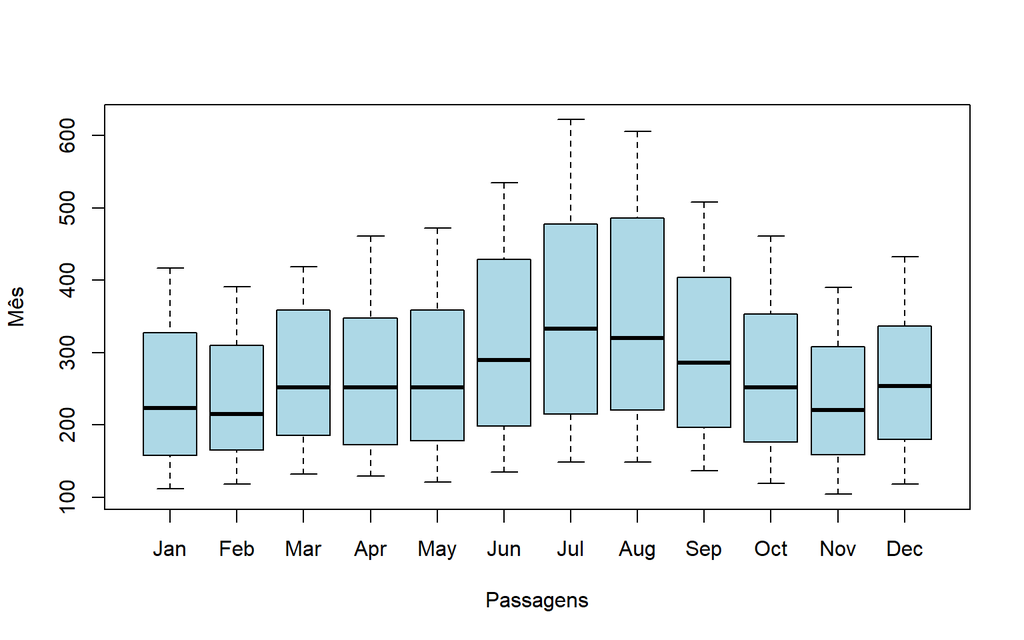

```r
boxplot(AP ~ cycle(AP),
        names = month.abb,
        col = "lightblue",
        xlab = "Passagens",
        ylab = "Mês",
        cex.main = 0.9)
```

Fonte: Box and Jenkins (1976).

A mesma análise é conduzida na série ganhos trimestrais por ação da empresa Johnson & Johnson. A **Figura 7** apresenta o comportamento da série após a remoção da componente de sazonalidade. Visualmente, torna-se mais evidente que a série possui uma tendência determinística de natureza exponencial.

Figura 7 - Componente de tendência da série ganhos trimestrais por ação da empresa Johnson & Johnson

```r
jj <- lista_dados$jj
jj.ts <- ts(jj, start=1960, frequency=4)
dygraph(aggregate(jj.ts), main = "") %>%
  dyRangeSelector(height = 40) %>%
  dySeries("V1", label = "Ganhos por ação") %>%
  dyOptions(fillGraph = TRUE, fillAlpha = 0.1) %>%
  dyHighlight(highlightCircleSize = 5,
              highlightSeriesBackgroundAlpha = 0.2,
              hideOnMouseOut = FALSE)
```

[interactive chart not shown]

Fonte: Shumway and Stoffer (2006).

A **Figura 8**, por sua vez, apresenta as distribuições dos ganhos por ação agrupadas por trimestre. O padrão de sazonalidade nesta série é menos acentuado do que na análise anterior; contudo, ainda é possível inferir que os ganhos por ação são mais elevados no terceiro trimestre e mais baixos no primeiro. Nota-se, ainda, a presença de um valor atípico (outlier) neste primeiro trimestre.

Figura 8 - Sazonalidade Trimestral

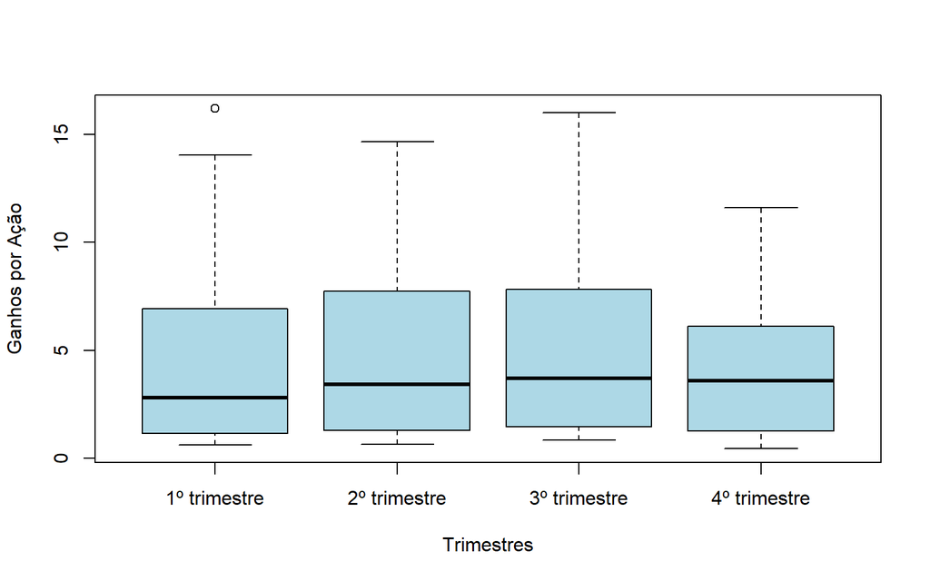

```r
boxplot(jj.ts ~ cycle(jj.ts),
        names = c("1º trimestre", "2º trimestre", "3º trimestre", "4º trimestre"),
        col = "lightblue",
        xlab = "Trimestres",
        ylab = "Ganhos por Ação",
        cex.main = 0.9)
```

Fonte: Shumway and Stoffer (2006).

A **Figura 9** apresenta a série da taxa mensal de desemprego no estado do Maine (EUA), abrangendo o período de janeiro de 1996 a agosto de 2006. Esta série possui um comportamento peculiar, caracterizado por uma reversão drástica da tendência entre os anos 2000 e 2001. Séries com esse comportamento exibem o que se denomina quebra estrutural.

A quebra estrutural pode ser entendida, em termos gerais, como a perda de estabilidade de um processo ao longo do tempo. Analogamente, imagine a medição da temperatura de uma sala a cada minuto: se uma janela for aberta em pleno inverno, a média da temperatura sofrerá uma queda brusca e permanecerá em um novo patamar. Uma quebra estrutural ocorre quando os parâmetros estatísticos de uma série temporal (como a média, a tendência ou a variância) sofrem uma mudança repentina e persistente em um ponto específico do tempo. Não se trata de uma oscilação comum ou de um ruído estatístico, mas de uma alteração no comportamento fundamental da série.

As quebras estruturais manifestam-se, basicamente, de três formas principais:

- **Mudança no Nível (Média)**: a série “salta” para um novo patamar (para cima ou para baixo).
- **Mudança na Inclinação (Tendência)**: a série crescia a uma taxa e passa a crescer mais rápido, mais devagar ou começa a cair. Comportamento observado na Serie da Figura 9.
- **Mudança na Volatilidade (Variância)**: a série era estável e, subtamente, torna-se muito instável (alta variabilidade).

Até o ponto em que a série sofreu a quebra estrutural, observava-se uma tendência decrescente. Após esse evento, a série passou a apresentar uma tendência crescente até determinado período, a partir do qual demonstra certa estabilidade ou estacionariedade.

Figura 9 - Taxa mensal de desemprego no estado do Maine, Estados Unidos (janeiro de 1996 a agosto de 2006)

```r
maine <- lista_dados$Maine
maine.ts <- ts(maine, start = c(1996, 1), freq = 12)

# Gráfico interativo:
dygraph(maine.ts,
        main = "",
        height = 300, width = "80%") %>%
  dyRangeSelector(height = 40) %>%
  dySeries("V1", label = "Taxa") %>%
  dyOptions(fillGraph = TRUE, fillAlpha = 0.1) %>%
  dyHighlight(highlightCircleSize = 5,
              highlightSeriesBackgroundAlpha = 0.2,
              hideOnMouseOut = FALSE)
```

[interactive chart not shown]

Fonte: Cowpertwait and Metcalfe (2009).

As **Figuras 10 e 11** apresentam a série mensal e as componentes de tendência e sazonalidade que foram extraídas. O padrão anual de comportamento das taxas de desemprego no estado do Maine, no período de janeiro de 1996 a agosto de 2006, torna-se evidente nos diagramas de caixa (boxplots) da Figura 11.

Figura 10 - Serie Mensal e Tendência para a taxa mensal de desemprego no Estado do Maine

```r
g1 <- dygraph(maine.ts, group = "maine",
              main = "<span style='font-size: 14px;'>Série Mensal",
              height = 300, width = "80%") %>%
  dySeries("V1", label = "Taxa Desemprego (%)") %>%
  dyOptions(fillGraph = TRUE, fillAlpha = 0.1)

g2 <- dygraph(aggregate(maine.ts), group = "maine",
              main = "<span style='font-size: 14px;'>Tendência",
              height = 300, width = "80%") %>%
  dySeries("V1", label = "Média Anual") %>%
  dyOptions(colors = "red")

browsable(tagList(
  div(g1, style = "margin-bottom: 20px;"),
  div(g2, style = "margin-bottom: 20px;")
))
```

[interactive chart not shown]

Fonte: Cowpertwait and Metcalfe (2009).

Figura 11 - Sazonalidade para a taxa mensal de desemprego no estado do Maine

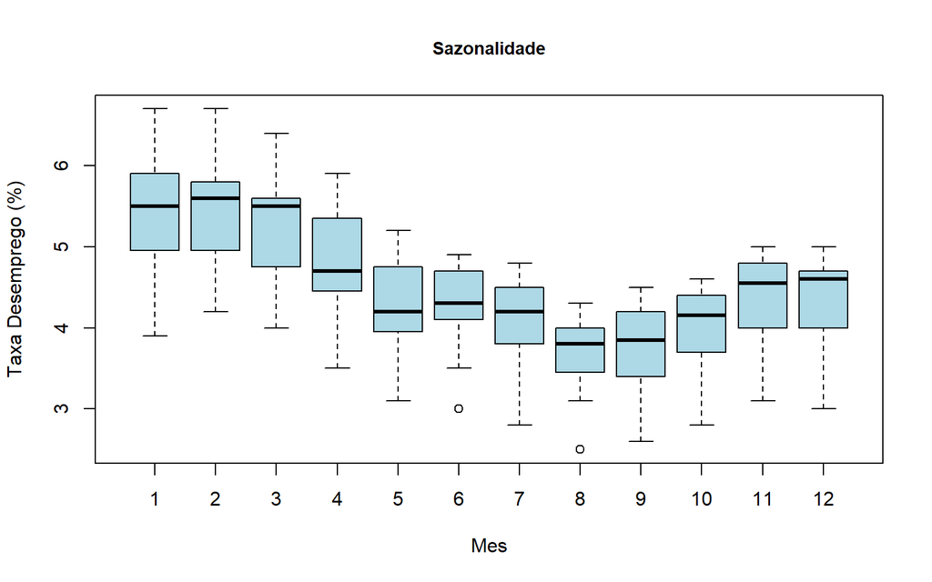

```r
boxplot(maine.ts ~ cycle(maine.ts),
        col = "lightblue",
        main = "Sazonalidade",
        xlab = "Mes",
        ylab = "Taxa Desemprego (%)",
        cex.main = 0.9)
```

Fonte: Cowpertwait and Metcalfe (2009).

#### **1.4 Trabalhando com múltiplas séries**

É possível analisar o comportamento de múltiplas séries temporais observadas no mesmo período e com a mesma periodicidade. Imagine este exercício como a observação do painel de controle de uma aeronave: um único medidor informa a altitude, mas a compreensão completa do voo só é possível ao cruzar essa informação com a velocidade, a pressão e o combustível. De modo geral, essa prática insere-se no campo da análise multivariada ou do estudo de cointegração (relações de longo prazo). O objetivo é compreender como uma série influencia a outra (correlação e causalidade), seja no curto ou no longo prazo. Enquanto a correlação mede o grau de associação linear entre as séries, a causalidade refere-se à influência ou ao efeito do comportamento de uma série $A$ sobre uma série $B$, ou como ambas podem ser afetadas por uma terceira série $C$.

Ao utilizar múltiplas séries, é possível construir modelos que buscam compreender essas inter-relações, o que pode ampliar significativamente o poder de previsão. Embora seja um tema de suma relevância, a análise multivariada extrapola o escopo deste curso introdutório.

A **Figura 12** apresenta o comportamento de três séries com a mesma periodicidade, observadas no mesmo intervalo de tempo (janeiro de 1958 a dezembro de 1990) na Austrália:

1. Fornecimento mensal de eletricidade (milhões de kWh);
2. Consumo de cerveja (ml);
3. Produção de produtos à base de chocolate (toneladas).

Figura 12 - Multiplas Séries: fornecimento mensal de eletricidade, consumo de cerveja e produção de chocolate, Austália (1958-1990)

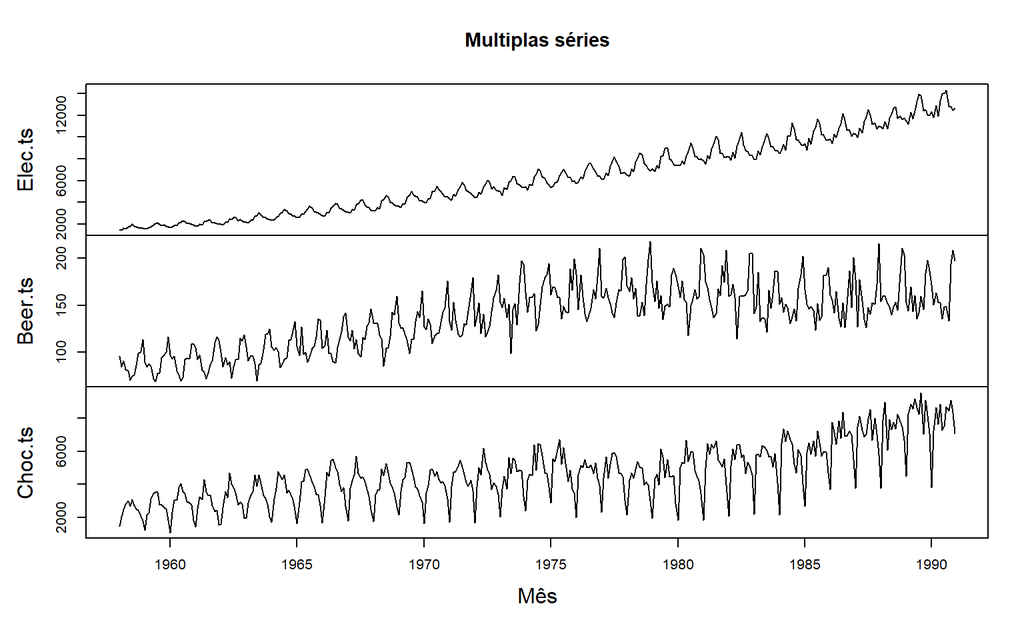

```r
cbe <- lista_dados$cbe

Elec.ts <- ts(cbe[, 3], start = 1958, freq = 12)
Beer.ts <- ts(cbe[, 2], start = 1958, freq = 12)
Choc.ts <- ts(cbe[, 1], start = 1958, freq = 12)

plot(cbind(Elec.ts, Beer.ts, Choc.ts),
     main = "Multiplas séries",
     xlab = "Mês",
     cex.main = 0.9)
```

Fonte: Cowpertwait and Metcalfe (2009).

É possível utilizar a função `ts.intersect` para obter a interseção de duas séries temporais que se sobrepõem cronologicamente. Na **Figura 13**, as séries número mensal de passagens aéreas emitidas e fornecimento mensal de eletricidade são apresentadas exclusivamente no período em que coincidem. Observa-se um comportamento muito similar entre as séries número de passageiros por mês e consumo mensal de energia.

Figura 13 - Interseção das séries número de passageiros e fornecimento mensal de eletricidade (1958 a 1960)

```r
data("AirPassengers")
AP = AirPassengers

AP.elec <- ts.intersect(AP, Elec.ts)

g1 <- dygraph(AP.elec[,1],
              main = "<span style='font-size: 14px;'>Passagens emitidas por mês</span>",
              height = 300, width = "95%") %>%
  dySeries("V1", label = "Passagens") %>%
  dyAxis("x", label = "Ano / Mês") %>%
  dyAxis("y", label = "Nº de Passageiros") %>%
  dyOptions(fillGraph = TRUE,
            fillAlpha = 0.1,
            labelsKMB = TRUE) %>%
  dyCSS(textConnection(".dygraph-axis-label-x { margin-top: 10px; }
                        .dygraph-axis-label-y { margin-left: -10px; }"))

g2 <- dygraph(AP.elec[,2],
              main = "<span style='font-size: 14px;'>Consumo mensal de energia</span>",
              height = 300, width = "95%") %>%
  dySeries("V1", label = "Consumo") %>%
  dyAxis("x", label = "Ano / Mês") %>%
  dyAxis("y", label = "Consumo (kWh)") %>%
  dyOptions(fillGraph = TRUE, fillAlpha = 0.1, colors = "blue")

library(htmltools)
browsable(tagList(
  div(g1, style = "margin-bottom: 20px;"),
  div(g2, style = "margin-bottom: 20px;")
))
```

[interactive chart not shown]

É possível, também, gerar um diagramas de dispersão (*scatterplot*) das séries sobrepostas para avaliar graficamente o grau de associação entre elas, conforme ilustrado na **Figura 14**. Uma linha de regressão linear é traçada (em vermelho), demonstrando um ajuste linear razoável para a relação, que também apresenta um coeficiente de correlação relativamente elevado $(\rho = 0,88)\hspace{0.5cm}$.

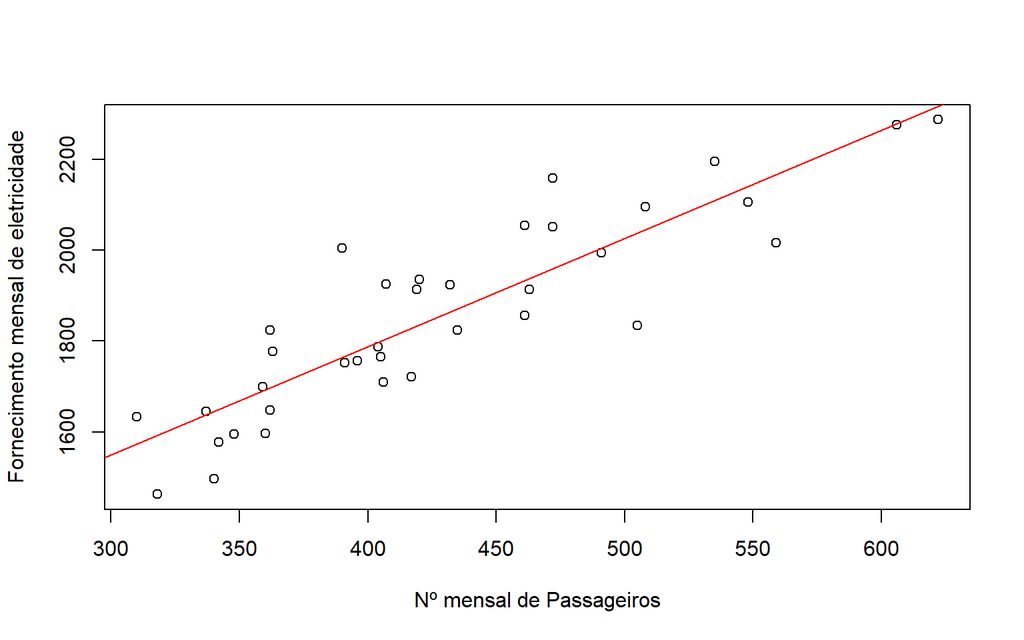

```r
ap <- as.vector(AP.elec[,1])
elec <- as.vector(AP.elec[,2])

plot(ap, elec,
     xlab = "Nº mensal de Passageiros",
     ylab = "Fornecimento mensal de eletricidade")

abline(reg = lm(elec ~ ap), col="red")
```

```r
cor(ap, elec)
```

```
## [1] 0.8841668
```

#### **1.5 Decomposição de séries**

Nos exemplos anteriores, os padrões de tendência e sazonalidade eram evidentes por meio da análise gráfica. Contudo, para certos tipos de séries, tais padrões não são tão óbvios, exigindo métodos analíticos distintos. Séries financeiras, por exemplo, costumam sofrer “choques” e apresentar mudanças drásticas em sua trajetória, fenômeno denominado *quebra estrutural*.

A função `decompose` no R estima os efeitos de tendência e sazonalidade de séries temporais utilizando o método de médias móveis centradas. O objeto resultante pode ser utilizado como argumento na função plot para exibir, de forma conjunta, a série original e suas componentes decompostas: tendência, sazonalidade e o erro aleatório (resíduo).

Um parâmetro fundamental da função `decompose` é o `type`, que define a natureza do modelo: aditivo (`additive`) ou multiplicativo (`multiplicative`).

A **Figura 15** apresenta os códigos e o resultado da decomposição da série de taxas mensais de desemprego no Maine (EUA), observada de janeiro de 1996 a agosto de 2006. Visto que a magnitude da componente sazonal não aumenta proporcionalmente ao nível da série ao longo do tempo (variabilidade constante), aplica-se a decomposição por modelo aditivo. Como a distinção entre os modelos reside no comportamento da variabilidade, a escolha entre um tipo ou outro impacta diretamente a estrutura do termo residual.

Figura 15 - Decomposição estrutural da série taxa mensal de desemprego no estado do Maine

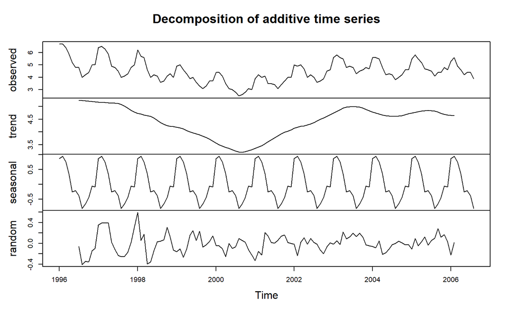

```r
maine <- lista_dados$Maine
maine.ts <- ts(maine, start = c(1996, 1), freq = 12)

dec <- decompose(maine.ts, type="add")
plot(dec)
```

A **Figura 16** apresenta o código utilizado e os resultados da decomposição de uma série temporal com estrutura multiplicativa. A série analisada refere-se ao fornecimento mensal de eletricidade, mensurado em milhões de kWh.

Figura 16 - Decomposição estrutural da série fornecimento mensal de eletricidade (em milhões de kWh)

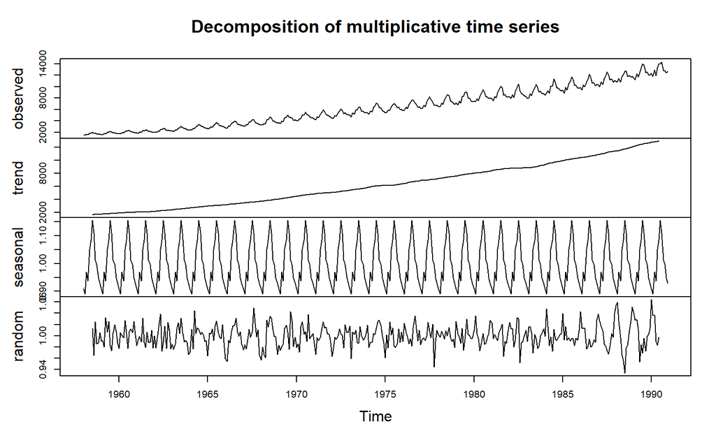

```r
cbe <- lista_dados$cbe
Elec.ts <- ts(cbe[, 3], start = 1958, freq = 12)

dec <- decompose(Elec.ts, type="mult")
plot(dec)
```

Caso o objetivo seja analisar isoladamente os componentes de tendência e sazonalidade, uma alternativa consiste na utilização dos códigos empregados para gerar a **Figura 17**.

Figura 17 - Componentes de Tendência e Sazonalidade da série fornecimento mensal de eletricidade (em milhões de kWh)

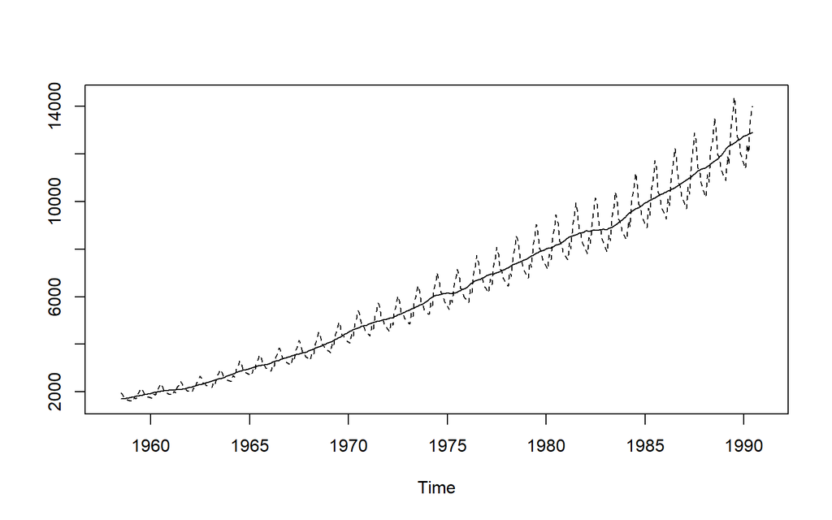

```r
cbe <- lista_dados$cbe
Elec.ts <- ts(cbe[, 3], start = 1958, freq = 12)

Elec.decom <- decompose(Elec.ts, type = "mult")
Trend <- Elec.decom$trend
Seasonal <- Elec.decom$seasonal

ts.plot(cbind(Trend, Trend * Seasonal), lty = 1:2)
```

#### **1.6 Estimando a tendência: suavização**

Existem diversos métodos para estimar a tendência de uma série temporal, sendo o modelo linear a abordagem mais simplificada. Um procedimento robusto para tendências não lineares (que não pressupõe uma forma funcional específica) é a **Média Móvel Centrada (MMC)**. Este método consiste no cálculo da média de um número predeterminado de observações da série, distribuídas simetricamente em torno de cada ponto no tempo, com exceção das extremidades inicial e final.

##### **1.6.1 Média Móvel Centrada (MMC)**

A MMC é uma técnica fundamental para isolar a componente de tendência-ciclo, especialmente em séries que apresentam sazonalidade. Diferente da média móvel simples (que considera apenas observações pretéritas), a versão centrada utiliza janelas que se estendem de forma simétrica para o passado e para o futuro.

Seja $Z_t$ uma série temporal observada. A média móvel de ordem $m$ é definida pela média aritmética da série dentro de uma janela de largura $m$. Para que a estimativa da tendência no instante $t$ seja centrada, os pontos devem ser distribuídos equidistantemente em relação a $t$.

**Média Móvel com período ímpar $(m = 2k + 1)\hspace{0.5cm}$:**

Neste caso, a centralização é direta. A tendência estimada no ponto $t$ é a média do valor atual, acrescida de $k$ pontos anteriores e $k$ pontos posteriores a $t$:

$$\hat{T}_t = \frac{1}{m} \sum_{j=-k}^{k}
Z_{t+j}\hspace{3cm}(1.3)$$
Exemplo: Se $m=3\hspace{0.2cm}$, então $k=1\hspace{0.2cm}$. Logo, $\hat{T}_t = \frac{1}{3}(Z_{t-1} + Z_t + Z_{t+1})\hspace{0.6cm}$.

**Média Móvel com período par $(m = 2k)\hspace{0.3cm}$:**

Quando a periodicidade é par (comum em dados trimestrais, $m=4\hspace{0.2cm}$, ou mensais, $m=12\hspace{0.2cm}$), a média simples resultaria em um valor posicionado entre dois intervalos temporais (ex.: entre junho e julho). Para alinhar o valor exatamente ao instante $t$, aplica-se uma segunda média móvel de ordem 2 sobre o resultado da primeira. A fórmula da MMC de ordem $m$ é expressa por:

$$\hat{T}_t = \frac{1}{m} \left[
\frac{1}{2}Z_{t-k} + Z_{t-k+1} + \dots + Z_{t+k-1} + \frac{1}{2}Z_{t+k}
\right]\hspace{3cm}(1.4)$$
Nesta configuração, os pesos das extremidades são reduzidos à metade para garantir a simetria e assegurar que a soma dos pesos seja unitária.

**CURIOSIDADE: Derivação da Equação (1.4)**

Para uma série trimestral ($m=4\hspace{0.2cm}$), o processo ocorre em etapas:

**Passo 1:** Calculam-se as médias móveis simples de ordem 4 em instantes sucessivos que incidem em pontos médios do intervalo:

- $M_{t-0.5} = \frac{1}{4}(Z_{t-2} + Z_{t-1} + Z_t + Z_{t+1})$
- $M_{t+0.5} = \frac{1}{4}(Z_{t-1} + Z_t + Z_{t+1} + Z_{t+2})$

Veja que usamos os delocamento de $0.5$ unidade de tempo e não de $1$ unidade inteira. Quando temos um número par de observações ($m=4\hspace{0.2cm}$), a média aritmética “cai no meio do caminho” entre dois tempos inteiros. Ao se calcular a média de 4 pontos, por exemplo, dos tempos $t=1, 2, 3, 4\hspace{0.5cm}$, temos:

$\frac{1+2+3+4}{4} = 2.5$

O valor resultante não pertence ao tempo 2 nem ao tempo 3; ele está posicionado exatamente em 2.5.

**Passo 2:** Centram-se esses valores $M_{t-0.5}\hspace{0.2cm}$ e $M_{t+0.5}\hspace{0.2cm}$ no instante $t$ através de uma nova média aritmética:

$$\hat{T}_t = \frac{M_{t-0.5} +
M_{t+0.5}}{2}$$
**Passo 3:** Substituindo e expandindo:

$$\hat{T}_t = \frac{1}{2} \left[
\frac{Z_{t-2} + Z_{t-1} + Z_t + Z_{t+1}}{4} + \frac{Z_{t-1} + Z_t +
Z_{t+1} + Z_{t+2}}{4} \right]$$
$$\hat{T}_t = \frac{\frac{1}{2}Z_{t-2} + Z_{t-1} +
Z_t + Z_{t+1} + \frac{1}{2}Z_{t+2}}{4}$$
A expansão resulta em um filtro com pesos $[\frac{1}{8}, \frac{1}{4}, \frac{1}{4}, \frac{1}{4}, \frac{1}{8}]\hspace{0.5cm}$ cuja soma é igual a 1.

Os objetivos precípuos da MMC são atenuar a sazonalidade e promover a suavização da série para facilitar a visualização da tendência. O grau de suavização é diretamente proporcional ao número de termos (janela) escolhido. No entanto, o método apresenta limitações, como a perda de informações nas extremidades da série e a subjetividade na escolha da janela ideal — embora esta última seja um desafio inerente a diversos métodos de suavização.

**Exemplo de aplicação da MMC**

A **Figura 18** ilustra o número de óbitos semanais por doenças cardiovasculares ao longo de uma década. No software R, a função `filter` permite selecionar o tipo de convolução via argumento `side` ($1$ para simples; $2$ para centrada). Neste exemplo, compararam-se janelas distintas para evidenciar o impacto da ordem da média no grau de suavização. Observa-se que, para séries epidemiológicas complexas, a definição do nível ótimo de suavização requer critério analítico apurado.

Figura 18 - Suavização da série de óbitos semanais por doenças cardiovasculares via Média Móvel Centrada (MMC), considerando um horizonte de 10 anos de observação

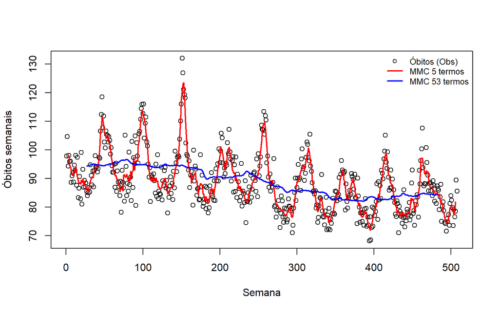

```r
morte <- lista_dados$cmort
morte.ts <- ts(morte)
t = 1:length(morte.ts)
# MMC:
ma5 = filter(morte.ts, sides=2, rep(1,5)/5)
ma53 = filter(morte.ts, sides=2, rep(1,53)/53)
# Gráfico:
plot(t, morte.ts, type="p", ylab="Óbitos semanais", xlab="Semana")
lines(ma5, col="red", lwd=2)
lines(ma53, col="blue", lwd=2)
legend("topright",
       legend = c("Óbitos (Obs)", "MMC 5 termos", "MMC 53 termos"),
       col = c("black", "red", "blue"),
       pch = c(1, NA, NA),
       lty = c(NA, 1, 1),
       lwd = c(NA, 2, 2),
       bty = "n",
       cex = 0.8)
```

Fonte: Shumway and Stoffer (2006).

##### **1.6.2 Regressão Localmente Ponderada (LOWESS)**

Existem outros métodos de suavização que, à semelhança da média móvel centrada, visam identificar o sinal ou a tendência subjacente em uma série temporal.

Um método amplamente difundido é o LOWESS (Locally Weighted Scatterplot Smoothing). Trata-se de uma técnica robusta para a suavização de dados e identificação de tendências não lineares, sem a necessidade de pressupor uma forma funcional global (como um ajuste linear ou parabólico).

A essência do LOWESS consiste na seleção de uma vizinhança de pontos em torno de cada observação, os quais fundamentam a estimativa da tendência por meio de regressões locais. Em vez de aplicar uma regressão única ao conjunto total de dados, o método executa múltiplas regressões ponderadas. Para cada ponto $x_i$, o procedimento compreende as seguintes etapas:

- Seleção de uma vizinhança de pontos ao redor de $x_i$.
- Atribuição de pesos superiores aos pontos mais próximos de $x_i$, reduzindo a influência das observações mais distantes.
- Ajuste de uma reta (ou polinômio de grau superior) a esses pontos ponderados.
- Definição do valor suavizado para $x_i$ como o valor previsto sobre a curva ajustada.

**CURIOSIDADE: Formalização matemática do método LOWESS**

Para cada ponto de interesse $x_0$, o algoritmo executa as seguintes etapas:

**Passo 1: Seleção da vizinhança (parâmetro de suavização $f$)**

Define-se uma fração $f$ do número total de observações ($n$). Por exemplo, se $n=100\hspace{0.2cm}$ e $f = 0,2\hspace{0.2cm}$, utilizam-se os 20 vizinhos mais próximos de $x_0$. A distância entre $x_0$ e o vizinho mais remoto dentro dessa janela é denotada por $d(x_0)$.

**Passo 2: Atribuição de pesos (Função Tricúbica)**

Calcula-se o peso $w_i$ para cada vizinho $x_i$ contido na janela definida por $f$. A função de ponderação mais usual é a tricúbica:

$$w_i(x_0) = \left( 1 - \left| \frac{x_i -
x_0}{d(x_0)} \right|^3 \right)^3$$
Nesta formulação, se $x_i = x_0\hspace{0.2cm}$, o peso é máximo ($1$). Caso $x_i$ esteja no limite da vizinhança, o peso converge a $0$.

**Passo 3: Regressão Linear Local Ponderada** Aplica-se o método de Mínimos Quadrados Ponderados para estimar os coeficientes $\hat{\beta}_0$ e $\hat{\beta}_1$ que minimizam a soma dos resíduos quadráticos, ponderada pelos pesos $w_i$:

$$\sum_{i=1}^{k} w_i(x_0) (y_i - (\beta_0
+ \beta_1 x_i))^2$$
**Passo 4: Obtenção do valor suavizado** O valor suavizado para o ponto $x_0$ (denotado por $\hat{y}_0$) corresponde ao valor predito pela equação da reta localmente ajustada:

$$\hat{y}_0 = \hat{\beta}_0 +
\hat{\beta}_1 x_0$$

Este procedimento é iterado para todos os pontos do conjunto de dados até a composição da curva suavizada completa.

O algoritmo LOWESS original inclui uma etapa adicional para o tratamento de outliers (valores discrepantes). Após o ajuste inicial, analisam-se os resíduos (o erro associado a cada observação). Pontos que apresentam resíduos elevados recebem um ‘peso de robustez’ reduzido em uma rodada subsequente de cálculos. Esse procedimento assegura que a curva estimada não seja indevidamente influenciada por dados anômalos.

O método LOWESS apresenta pelo menos duas vantagens fundamentais em relação à Média Móvel Centrada (MMC): preserva as observações nas extremidades da série e possui maior resiliência a outliers. Em termos estatísticos, o LOWESS é considerado mais robusto e versátil. Enquanto a MMC limita-se ao cálculo da média aritmética local, o LOWESS ajusta regressões lineares locais ponderadas, atribuindo maior relevância às observações próximas ao centro da janela.

**Exemplo de aplicação do LOWESS**

Utilizaremos a mesma série temporal aplicada ao método da Média Móvel Centrada para fins comparativos. A **Figura 19** apresenta o código empregado e os distintos ajustes (suavizações) para o número de óbitos semanais por doenças cardiovasculares, observados ao longo de um horizonte de 10 anos.

Figura 19 - Suavização da série de óbitos semanais por doenças cardiovasculares via método LOWESS, considerando diferentes parâmetros de ajuste e um horizonte de 10 anos de observação

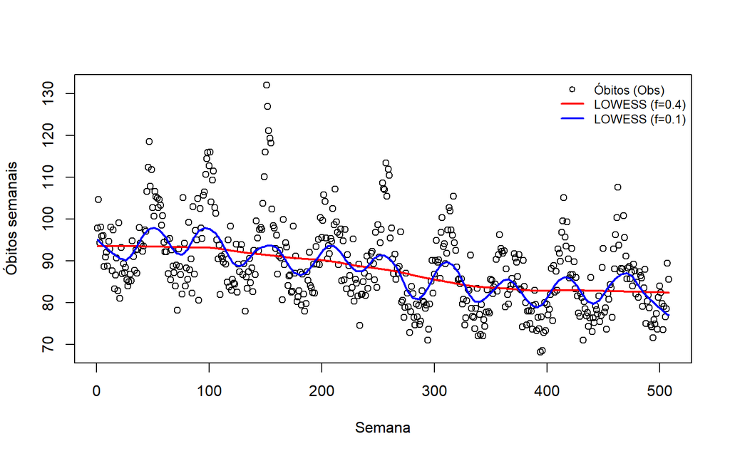

```r
morte <- lista_dados$cmort
morte.ts <- ts(morte)
t = 1:length(morte.ts)

# Gráfico com LOEWSS:
plot(t, morte.ts, type="p", ylab="Óbitos semanais", xlab="Semana")
lines(lowess(morte.ts, f=0.4), col="red", lwd=2)
lines(lowess(morte.ts, f=0.1), col="blue", lwd=2)
legend("topright",
       legend = c("Óbitos (Obs)", "LOWESS (f=0.4)", "LOWESS (f=0.1)"),
       col = c("black", "red", "blue"),
       pch = c(1, NA, NA),
       lty = c(NA, 1, 1),
       lwd = c(NA, 2, 2),
       bty = "n",
       cex = 0.8)
```

Fonte: Shumway and Stoffer (2006).

### **2. Modelos de Suavização Exponencial**

Os modelos de suavização exponencial constituem uma das abordagens fundamentais na análise de séries temporais, permitindo a decomposição da série em três componentes principais: **nível**, **tendência** e **sazonalidade**. Entre as metodologias de maior relevância e aplicabilidade prática, destaca-se o método de Holt-Winters (Holt 2004; Winters 1960), amplamente implementado em softwares estatísticos como o R.

#### **2.1 Suavização Exponencial Simples (SES)**

Indicada para séries estacionárias (ausência de tendência ou sazonalidade persistente), a Suavização Exponencial Simples estima o nível da série ao atenuar o ruído aleatório:

$$\large L_{t} = \alpha Z_{t} + (1 -
\alpha) L_{t-1}\hspace{3cm}(2.1)$$
Onde:

- $Z_{t}$: valor observado no tempo $t$.
- $L_{t}$: nível estimado (suavizado) no tempo $t$.
- $\alpha$: constante de suavização $(0 \le \alpha \le 1)\hspace{0.4cm}$.

O parâmetro $\alpha$ determina a ponderação atribuída à observação mais recente. Valores de $\alpha$ próximos a 1 indicam que o modelo prioriza dados recentes em detrimento do histórico; valores próximos a 0 resultam em uma resposta mais lenta a mudanças estruturais na série..

**CURIOSIDADE: A natureza exponencial dos pesos**

Ao expandir a equação de $L_t$ recursivamente, substituindo $L_{t-1}$ por sua respectiva definição, obtemos:

$$L_t = \alpha Z_t +
\alpha(1-\alpha)Z_{t-1} + \alpha(1-\alpha)^2Z_{t-2} + \dots$$
Nota-se que os pesos atribuídos às observações anteriores — $(\alpha, \alpha(1-\alpha), \alpha(1-\alpha)^2, \dots)\hspace{0.5cm}$ — decrescem exponencialmente conforme a antiguidade dos dados aumenta. Consequentemente, o modelo confere maior relevância estatística aos eventos recentes, reduzindo progressivamente o impacto do passado remoto na estimativa atual.

**Exemplo de aplicação do SES:**

A **Figura 20** ilustra uma série simulada que apresenta comportamento estacionário; isto é, possui variância e média constantes ao longo do tempo.

Figura 20 - Série simulada com comportamento estacionário

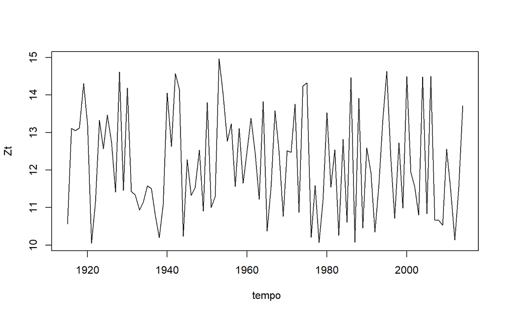

```r
set.seed( 1234)
Zt = ts(runif(100, 10, 15), start = c(1915, 1), frequency = 1)
plot(Zt, xlab =' tempo')
```

Todos os modelos de suavização exponencial aqui discutidos estão integrados na função `HoltWinters` do pacote `base` do R. Esta função permite a estimação dos parâmetros para o modelo completo (incluindo tendência e sazonalidade), conforme será detalhado adiante. Para estimar o parâmetro $\alpha$ do modelo SES, basta omitir os argumentos $\beta$ e $\gamma$, que correspondem, respectivamente, aos componentes de tendência e sazonalidade.

O código e o gráfico da **Figura 21** ilustram o processo de estimação e previsão da série simulada anteriormente (Figura 20). A série representada pela linha vermelha resulta da aplicação da equação (2.1), com um parâmetro estimado de $\alpha = 0,1016823\hspace{0.5cm}$. Tal valor indica que o modelo atribui baixa ponderação às informações recentes e maior peso ao histórico acumulado $(1-\alpha)\hspace{0.2cm}$ .

A explicação para essa estimativa reside na natureza da série, que foi simulada a partir de uma distribuição uniforme, replicando o comportamento de um *ruído branco uniforme* com intervalo $[10, 15]\hspace{0.2cm}$. Este tipo de série constitui um exemplo fidedigno de estacionariedade estrita e independência. Em séries com tais características, a observação atual não fornece informação preditiva sobre valores futuros (ausência de memória). Ademais, visto que os dados oscilam aleatoriamente em torno de uma média fixa $(12,5)$ , a estimativa mais robusta para o horizonte de previsão não é o último valor observado, mas sim a média histórica da série.

Figura 21 - Estimação e previsão da série simulada Zt pelo modelo SES

```r
modelo <-HoltWinters(Zt, beta = FALSE, gamma = FALSE)
modelo
```

```
## Holt-Winters exponential smoothing without trend and without seasonal component.
##
## Call:
## HoltWinters(x = Zt, beta = FALSE, gamma = FALSE)
##
## Smoothing parameters:
##  alpha: 0.1016823
##  beta : FALSE
##  gamma: FALSE
##
## Coefficients:
##       [,1]
## a 11.92001
```

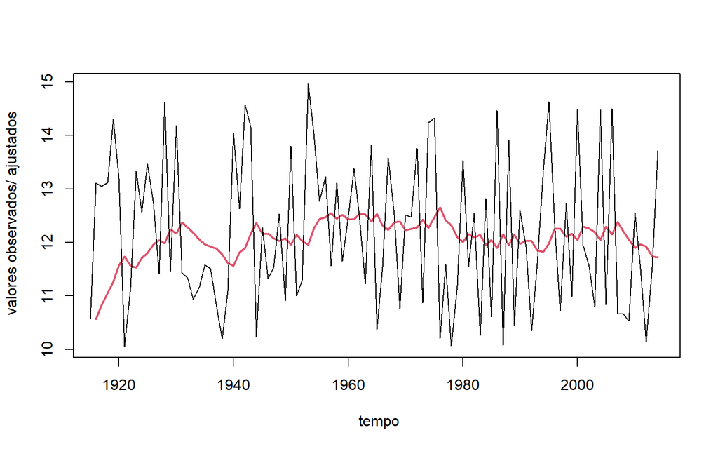

```r
plot(modelo, xlab =' tempo', ylab =' valores observados/ ajustados', main ='',
     lwd=2)
```

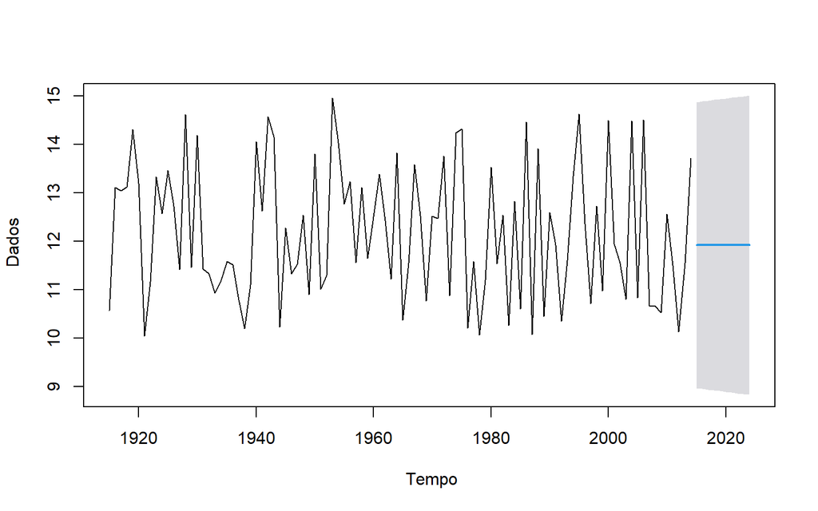

```r
# Previsão:
library(forecast)
ajuste_prev <- forecast( modelo, h = 10, level = 95)
plot(ajuste_prev, main ="", xlab =" Tempo", ylab =" Dados")
```

O processo de estimação via função `HoltWinters` visa minimizar o erro quadrático de previsão. Caso o algoritmo atribuísse uma ponderação elevada à informação recente $(\alpha \to 1)$ , a linha de ajuste mimetizaria o ruído estocástico (as flutuações aleatórias de $Z_t$ na Figura 20), resultando em um aumento do erro de generalização. Ao estimar um $\alpha$ reduzido, o modelo produz uma trajetória suavizada que converge para a média, minimizando estatisticamente o erro em séries puramente aleatórias.

Essa dinâmica suscita uma questão central: *em quais cenários o parâmetro $\alpha$ se aproximará da unidade*? O $\alpha$ tenderá a 1 (conferindo peso preponderante à observação mais recente) em séries que seguem um Passeio Aleatório (Random Walk) ou que apresentam mudanças abruptas e persistentes em seu nível. O conceito de Passeio Aleatório será aprofundado oportunamente, no módulo sobre processos estocásticos estacionários e não estacionários. Em síntese, o modelo SES estimará um $\alpha$ próximo de 1 em duas circunstâncias principais:

- **Séries com “memória” (Persistência):** Quando a observação atual constitui o melhor preditor para o valor subsequente. Exemplos clássicos incluem cotações de ativos financeiros ou taxas de câmbio em horizontes de curto prazo.
- **Mudanças de patamar (Quebras Estruturais):** Se o nível da série sofre um deslocamento súbito e permanente — por exemplo, de 10 para 50 — um $\alpha$ elevado permite que o modelo incorpore rapidamente o novo patamar, ajustando a estimativa do “novo normal”.

#### **2.2 Suavização Exponencial de Holt (SEH)**

O método de Holt é aplicado a séries temporais que apresentam uma tendência (ascendente ou descendente), mas que carecem de componente sazonal. Este modelo pressupõe que a série possui uma inclinação (*slope*), estimando o nível da série em cada instante por meio da seguinte equação:

$$\large L_{t} = \alpha Z_{t} + (1 -
\alpha)(L_{t-1} + T_{t-1}) \hspace{3cm}(2.2)$$
Onde $T_{t-1}$ representa a tendência estimada no período anterior.

Note que a estimativa do nível no instante $t$ incorpora a tendência prévia $T_{t-1}$ para mitigar o atraso (lag) sistemático em relação ao crescimento ou decréscimo da série. Assim, a equação (2.2) atualiza o nível base ao combinar a observação atual com o valor esperado (nível anterior acrescido da tendência anterior).

A componente de tendência, por sua vez, é estimada por:

$$\large T_{t} = \beta (L_{t} - L_{t-1}) +
(1 - \beta) T_{t-1} \hspace{3cm}(2.3)$$

Onde:

- $\beta$: Parâmetro de suavização da tendência $(0 \le \beta \le 1)\hspace{0.4cm}$ .
- O termo $[L_{t-1} + T_{t-1}]\hspace{0.4cm}$ representa a predição do nível para o instante $t$, formulada no período $t-1$ .

**CURIOSIDADE: Lógica Fundamental das Equações 2.2 e 2.3**

**O Nível $L_t$:**

Diferente do modelo SES, a expectativa para o período atual não se restringe ao nível anterior ($L_{t-1}$), mas engloba o nível anterior acrescido da tendência observada até então ($T_{t-1}$):

$$L_t = \alpha Z_t + (1 - \alpha)
\underbrace{[L_{t-1} + T_{t-1}]}_{\text{Previsão esperada}}$$
**A Tendência $T_t$:**

A tendência pode ser interpretada como a velocidade da série, determinada pela magnitude de sua inclinação (positiva ou negativa) entre dois instantes sucessivos. A estimativa atual da tendência ($\hat{T}_t$) resulta da ponderação entre a variação observada nos níveis e a tendência calculada anteriormente. A figura abaixo exemplifica o impacto do diferencial $L_{t} - L_{t-1}\hspace{0.2cm}$ na inclinação da série.

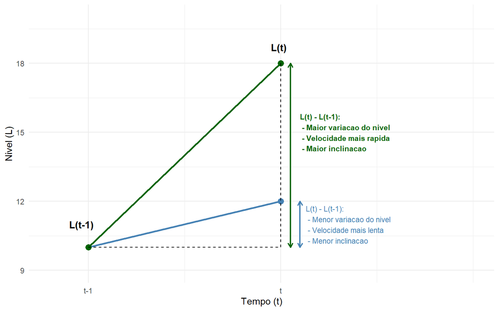

Conforme ilustrado na figura anterior, quanto maior a variação vertical, maior será a velocidade de crescimento (inclinação) da série entre os instantes $t-1$ e $t$. Em outros termos, a inclinação observada no presente é definida pela diferença entre o nível atual e o imediatamente anterior $(L_t - L_{t-1})\hspace{0.4cm}$. A mesma lógica aplica-se a inclinações ou variações negativas (decréscimos).

A formulação de Holt aplica uma suavização sobre essa velocidade, ponderando a tendência observada e a estimativa prévia:

$$T_t = \beta \underbrace{(L_t -
L_{t-1})}_{\text{Tendência medida agora}} + (1 - \beta)
T_{t-1}$$

**Exemplo de aplicação do SEH:**

Emprega-se a mesma função utilizada no modelo SES (`HoltWinters`). Contudo, para este ajuste, habilitam-se os argumentos $\alpha$ e $\beta$, que representam, respectivamente, os parâmetros de suavização do nível e da tendência.

A **Figura 22** ilustra a série temporal do consumo de energia elétrica (GWh) na Região Sudeste, abrangendo o período de janeiro de 1979 a janeiro de 2017. Observa-se uma tendência de crescimento aproximadamente linear, com um deslocamento de nível (possível quebra estrutural) em meados de 2000. Ao final do período, a série sugere uma alteração na inclinação da tendência. Visto que a componente sazonal não se apresenta de forma evidente, assume-se, para fins desta análise, que a série é livre de sazonalidade, procedendo-se com a predição via modelo SEH.

Figura 22 - Consumo de energia elétrica (Gwh) na Região Sudeste (1979 a 2017)

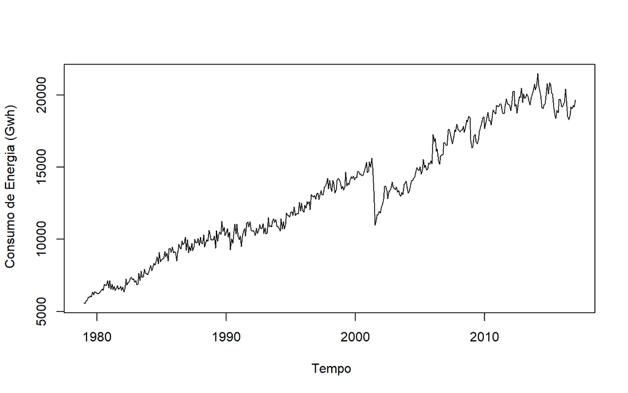

```r
energia <- lista_dados$energia
consumo <-ts( energia[, 2], start = c( 1979,1), frequency = 12)
plot( consumo, xlab =' Tempo', ylab =' Consumo de Energia (Gwh)', main ='')
```

A **Figura 23** ilustra o processo de estimação e os resultados da previsão para a série de consumo de energia elétrica na Região Sudeste, utilizando o modelo SEH. Observa-se que a estimativa para $\alpha$ foi de $0,7368304\hspace{0.5cm}$. Esse valor, mais próximo da unidade, decorre provavelmente da mudança de patamar (potencial quebra estrutural) e da alteração na inclinação observada no período final da série. Por outro lado, o valor estimado para $\beta$ foi de $0,01102303\hspace{0.5cm}$, indicando, conforme a equação (2.3), que se atribui baixa ponderação à tendência mais recente em favor da estabilidade do componente histórico.

Ao analisar a previsão para os 48 meses subsequentes $(h=48)\hspace{0.2cm}$ , nota-se, pelos valores médios previstos (linha azul), uma leve atenuação na inclinação da série, acompanhada de uma elevada incerteza (representada pela área sombreada em cinza, ao nível de 95% de confiança). Na prática, as quebras estruturais passadas e a recente mudança de inclinação tornam complexo determinar se a série sofrerá uma reversão definitiva de tendência (de positiva para negativa). Tais instabilidades na dinâmica da série são os principais fatores que contribuem para a amplitude dos intervalos de confiança no horizonte de longo prazo.

Figura 23 - Estimação e previsão da série consumo de energia elétrica na Região Sudeste

```r
ajuste_holt <- HoltWinters(consumo, gamma = FALSE)
ajuste_holt
```

```
## Holt-Winters exponential smoothing with trend and without seasonal component.
##
## Call:
## HoltWinters(x = consumo, gamma = FALSE)
##
## Smoothing parameters:
##  alpha: 0.7368304
##  beta : 0.01102303
##  gamma: FALSE
##
## Coefficients:
##         [,1]
## a 19558.2735
## b    21.3909
```

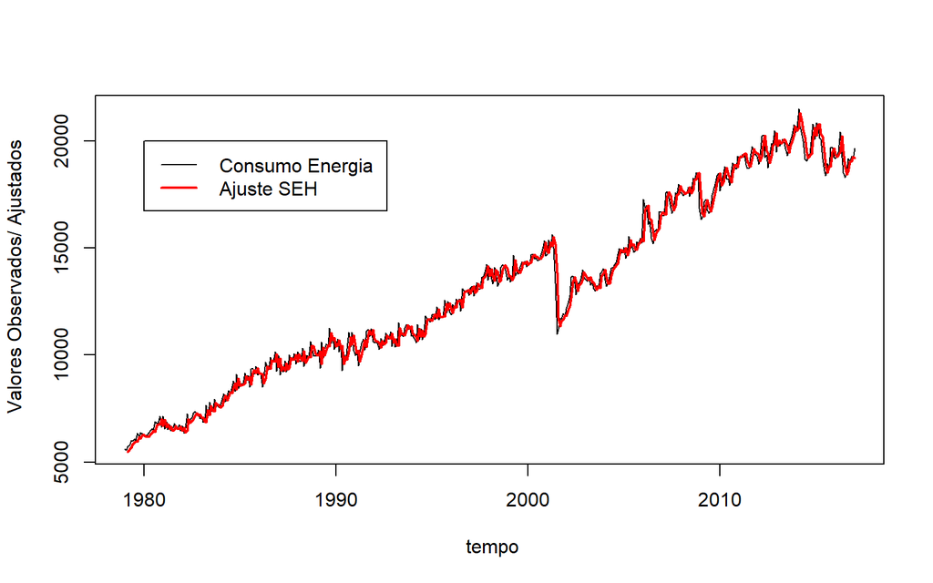

```r
plot( consumo, xlab =' tempo', ylab =' Valores Observados/ Ajustados', main ='')
lines( fitted(ajuste_holt)[, 1], lwd = 2, col =' red')
legend( 1980,20000, c(" Consumo Energia "," Ajuste SEH"),
        lwd = c( 1,2), col = c(" black"," red"), bty =' n')
```

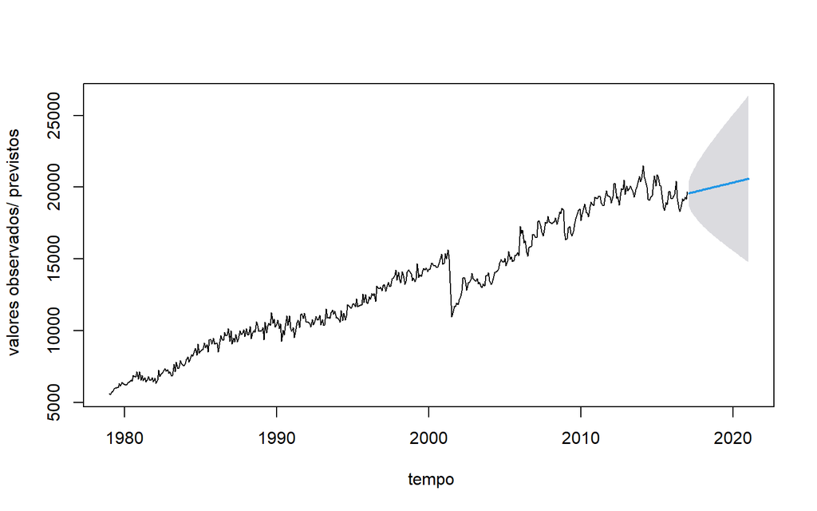

```r
# Previsão(h=48)
prev_holt <- forecast( ajuste_holt, h = 48, level = 95)
plot(prev_holt, xlab =' tempo', ylab =' valores observados/ previstos', main ='')
```

#### **2.3 Suavização Exponencial de Holt-Winters (SESH)**

O modelo de suavização exponencial tripla permite o tratamento simultâneo das componentes de tendência e sazonalidade. Sua aplicabilidade é ideal para séries que apresentam inclinação e ciclos repetitivos (ex.: picos de demanda em períodos festivos, vendas que aumentam todo mês de dezembro ou sazonalidade epidemiológica).

Existem duas variantes principais: o modelo Aditivo (onde a amplitude sazonal é constante) e o Multiplicativo (onde a sazonalidade é proporcional ao nível da série, apresentando comportamento expansivo). As equações abaixo descrevem o modelo Aditivo:

**Nível ($L_{t}$):**

$$\large L_{t} = \alpha [Z_{t} - S_{t-m}]
+ (1 - \alpha) [L_{t-1} + T_{t-1}]\hspace{3cm}(2.4)$$
Nesta etapa, subtrai-se a componente sazonal do período anterior ($S_{t-m}$) do valor observado para efetuar a dessazonalização dos dados e estimar o nível base.

**Tendência ($T_{t}$):**

$$\large T_{t} = \beta [L_{t} - L_{t-1}] +
(1 - \beta) T_{t-1}$$
Esta componente permanece idêntica à formulação do modelo de Holt.

**Sazonalidade ($S_{t}$):**

$$\large S_{t} = \gamma (Z_{t} - L_{t-1} -
T_{t-1}) + (1 - \gamma) S_{t-m} \hspace{3cm}(2.5)$$

Onde:

- $\gamma$ (gama): parâmetro de suavização sazonal $(0 \le \gamma \le 1)\hspace{0.5cm}$, responsável pela velocidade de adaptação do modelo ao padrão sazonal.
- $m$: periodicidade da sazonalidade (ex.: 4 para dados trimestrais, 12 para mensais).
- $S_{t-m}\hspace{0.5cm}(2.4)$: componente sazonal correspondente ao mesmo período no ciclo anterior.

Na equação (2.5), a componente sazonal é isolada ao subtrair o nível e a tendência do valor observado ($Z_t$). O parâmetro $\gamma$ determina a ponderação atribuída à observação mais recente em relação ao padrão sazonal histórico. Um $\gamma$ próximo a $0$ indica uma suavização intensa, pressupondo que o padrão sazonal é estável e persistente ao longo dos anos. Inversamente, um $\gamma$ próximo a $1$ sugere que a sazonalidade é volátil, conferindo maior relevância ao comportamento do ciclo mais recente.

**CURIOSIDADE: Lógica Fundamental da Equação 2.5**

O principal desafio deste modelo consiste em isolar o componente cíclico ou sazonal (ex.: o aumento sistemático de vendas em dezembro ou picos sazonais de doenças respiratórias no inverno).

**O Nível $L_t$:**

Para estimar o nível base, é necessário efetuar a dessazonalização do dado observado. Para tanto, subtrai-se $S_{t-m}$ (o efeito sazonal estimado para o mesmo período no ciclo anterior) do valor atual:

$$L_t = \alpha \underbrace{(Z_t -
S_{t-m})}_{\text{Dado dessazonalizado}} + (1 - \alpha) (L_{t-1} +
T_{t-1})$$
**A Sazonalidade $S_t$:**

A sazonalidade pode ser interpretada como o resíduo que “resta” do valor observado após a remoção da estrutura fundamental (nível e tendência). Em um modelo aditivo completo, teríamos $Z_t = L_t + T_t + S_t\hspace{0.5cm}$. Ao isolarmos $S_t$, a sazonalidade observada no instante atual seria $Z_t - L_t- T_{t-1}\hspace{0.5cm}$. Todavia, para mitigar o impacto de ruídos aleatórios sobre o componente cíclico, aplica-se uma média ponderada com o valor do ciclo anterior $(S_{t-m})$:

$$S_t = \gamma \underbrace{(Z_t - L_t -
T_{t-1})}_{\text{Sazonalidade medida agora}} + (1 - \gamma)
S_{t-m}$$

O modelo de Holt-Winters é a abordagem mais recomendada, dentre os modelos de suavização exponencial, para séries temporais que exibem comportamento sazonal. Esta metodologia constitui uma extensão, desenvolvida por Winters (1960), ao modelo original de Holt (1957), com o propósito específico de capturar e modelar flutuações sazonais. A estrutura preserva a lógica das equações de nível e tendência, incorporando, contudo, uma equação adicional para tratar a componente de sazonalidade.

O Quadro 1 apresenta uma síntese dos efeitos dos parâmetros no modelo de Suavização Exponencial de Holt-Winters.

Quadro 1 - Resumo dos Parâmetros dos modelos de suavização exponencial

| Parâmetro | Componente | Efeito |
| --- | --- | --- |
| $\alpha$ (Alpha) | Nível | Suaviza o valor médio da série. |
| $\beta$ (Beta) | Tendência | Suaviza a inclinação de crescimento/queda. |
| $\gamma$ (Gama) | Sazonalidade | Suaviza os padrões repetitivos (ciclos). |

**Exemplo de aplicação do SESH:**

Figura 24 - Investigando a sazonalidade da série de consumo de energia elétrica (Gwh) na Região Sudeste

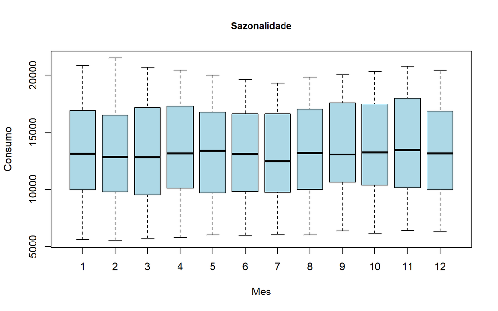

```r
boxplot(consumo ~ cycle(consumo),
        col = "lightblue",
        main = "Sazonalidade",
        xlab = "Mes",
        ylab = "Consumo",
        cex.main = 0.9)
```

A **Figura 25** ilustra o processo de estimação e previsão da série mediante a aplicação do modelo SESH (Holt-Winters), integrando a sazonalidade à estrutura do modelo. Os parâmetros estimados foram $\alpha=0,6983442 \hspace{0.5cm}$, $\beta=0,0009622944 \hspace{0.5cm}$ e $\gamma=0,3585297 \hspace{0.5cm}$. Mantendo o padrão anterior, $\alpha$ apresenta um valor próximo da unidade e $\beta$ aproxima-se de zero, evidenciando que o modelo prioriza informações recentes para o nível e mantém uma tendência histórica estável.

Por outro lado, o valor estimado para $\gamma$ não pode ser desprazado (embora mais próximo de 0 do que de 1); ele indica que a sazonalidade deve ser suavizada priorizando ligeiramente a média histórica dos ciclos anteriores, visto que o padrão sazonal da série é persistente e apresenta baixa volatilidade temporal. Ao comparar esta previsão com a da Figura 23, observa-se que o modelo atual incorpora com maior precisão a estrutura dos dados, uma vez que a estimativa pontual reflete as oscilações cíclicas. Adicionalmente, a incerteza sobre as previsões até o 48º mês foi reduzida, conforme demonstra a menor amplitude do intervalo de confiança (área sombreada em cinza) na Figura 25 em comparação à Figura 23.

```r
energia <- lista_dados$energia
consumo <-ts( energia[, 2], start = c( 1979,1), frequency = 12)
ajuste_holt <- HoltWinters(consumo)
ajuste_holt
```

```
## Holt-Winters exponential smoothing with trend and additive seasonal component.
##
## Call:
## HoltWinters(x = consumo)
##
## Smoothing parameters:
##  alpha: 0.6983442
##  beta : 0.0009622944
##  gamma: 0.3585297
##
## Coefficients:
##            [,1]
## a   19535.48813
## b      41.89821
## s1    -14.98555
## s2    -46.07129
## s3     93.26145
## s4   -432.30073
## s5   -652.26581
## s6   -703.54807
## s7   -176.36424
## s8    124.42431
## s9    306.93619
## s10   447.46989
## s11   -27.85833
## s12    45.97218
```

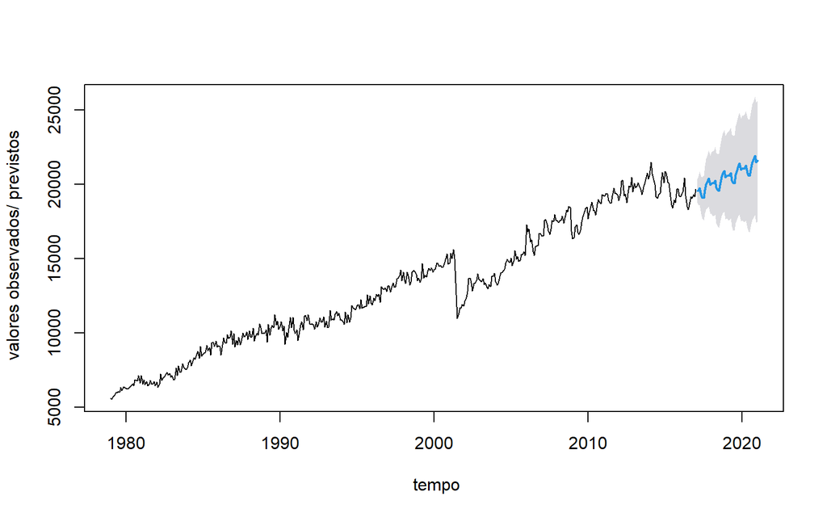

```r
# Previsão(h=48)
prev_holt <- forecast( ajuste_holt, h = 48, level = 95)
plot(prev_holt, xlab =' tempo', ylab =' valores observados/ previstos', main ='')
```

### **Declaração de Uso de Inteligência Artificial**

Declaro que ferramentas de Inteligência Artificial Generativa (IA) foram utilizadas como suporte na elaboração deste curso, especificamente nas seguintes etapas:

- **Desenvolvimento de Scripts:** Auxílio na estruturação de códigos em linguagem R para a geração de visualizações de dados e gráficos interativos.
- **Formatação Técnica:** Suporte na redação de sintaxe LaTeX integrada ao ambiente R Markdown.
- **Aprimoramento Textual:** Revisão gramatical, ortográfica e estilística da redação original.

Declaro, ainda, que o conteúdo foi revisado está em conformidade com a Portaria 2664/2026 do CNPq.

### **Referências**

Box, George, and GM Jenkins. 1976. “Analysis: Forecasting and Control.” *San Francisco* 10.

Cowpertwait, Paul SP, and Andrew V Metcalfe. 2009. *Introductory Time Series with r*. Springer Science & Business Media.

Holt, Charles C. 1957. “Forecasting Seasonals and Trends by Exponentially Weighted Moving Averages.”

———. 2004. “Forecasting Seasonals and Trends by Exponentially Weighted Moving Averages.” *International Journal of Forecasting* 20 (1): 5–10.

Shumway, Robert H, and David S Stoffer. 2006. *Time Series Analysis and Its Applications: With r Examples*. Springer.

Winters, Peter R. 1960. “Forecasting Sales by Exponentially Weighted Moving Averages.” *Management Science* 6 (3): 324–42.